# Risk Factor Analysis

## Outcome Variable

**Outcome Variable:** ever_stunted

## Predictor Variables

**Intervention Variable:** nchldlt5

**Adjustment Set:**

- arm
- W_mage
- meducyrs
- feducyrs
- hhwealth_quart
- hfoodsec
- W_mhtcm
- W_nrooms
- W_parity
- impfloor
- impsan
- safeh20
- delta_W_mage
- delta_meducyrs
- delta_feducyrs
- delta_hhwealth_quart
- delta_hfoodsec
- delta_W_mhtcm
- delta_W_nrooms
- delta_W_parity
- delta_impfloor
- delta_impsan
- delta_safeh20

## Stratifying Variables

The analysis was stratified on these variable(s):

- agecat
- studyid
- country

## Data Summary

| agecat | studyid | country | nchldlt5 | ever_stunted | n_cell | n |
| --- | --- | --- | --- | --- | --- | --- |
| 0-6 months | ki1000108-IRC | INDIA | 1 | 0 | 76 | 410 |
| 0-6 months | ki1000108-IRC | INDIA | 1 | 1 | 13 | 410 |
| 0-6 months | ki1000108-IRC | INDIA | 2 | 0 | 104 | 410 |
| 0-6 months | ki1000108-IRC | INDIA | 2 | 1 | 15 | 410 |
| 0-6 months | ki1000108-IRC | INDIA | 3+ | 0 | 180 | 410 |
| 0-6 months | ki1000108-IRC | INDIA | 3+ | 1 | 22 | 410 |
| 0-6 months | ki1017093b-PROVIDE | BANGLADESH | 1 | 0 | 461 | 700 |
| 0-6 months | ki1017093b-PROVIDE | BANGLADESH | 1 | 1 | 51 | 700 |
| 0-6 months | ki1017093b-PROVIDE | BANGLADESH | 2 | 0 | 161 | 700 |
| 0-6 months | ki1017093b-PROVIDE | BANGLADESH | 2 | 1 | 15 | 700 |
| 0-6 months | ki1017093b-PROVIDE | BANGLADESH | 3+ | 0 | 12 | 700 |
| 0-6 months | ki1017093b-PROVIDE | BANGLADESH | 3+ | 1 | 0 | 700 |
| 0-6 months | ki1017093c-NIH-Crypto | BANGLADESH | 1 | 0 | 467 | 758 |
| 0-6 months | ki1017093c-NIH-Crypto | BANGLADESH | 1 | 1 | 74 | 758 |
| 0-6 months | ki1017093c-NIH-Crypto | BANGLADESH | 2 | 0 | 180 | 758 |
| 0-6 months | ki1017093c-NIH-Crypto | BANGLADESH | 2 | 1 | 31 | 758 |
| 0-6 months | ki1017093c-NIH-Crypto | BANGLADESH | 3+ | 0 | 6 | 758 |
| 0-6 months | ki1017093c-NIH-Crypto | BANGLADESH | 3+ | 1 | 0 | 758 |
| 0-6 months | ki1066203-TanzaniaChild2 | TANZANIA, UNITED REPUBLIC OF | 1 | 0 | 1518 | 2385 |
| 0-6 months | ki1066203-TanzaniaChild2 | TANZANIA, UNITED REPUBLIC OF | 1 | 1 | 119 | 2385 |
| 0-6 months | ki1066203-TanzaniaChild2 | TANZANIA, UNITED REPUBLIC OF | 2 | 0 | 632 | 2385 |
| 0-6 months | ki1066203-TanzaniaChild2 | TANZANIA, UNITED REPUBLIC OF | 2 | 1 | 37 | 2385 |
| 0-6 months | ki1066203-TanzaniaChild2 | TANZANIA, UNITED REPUBLIC OF | 3+ | 0 | 75 | 2385 |
| 0-6 months | ki1066203-TanzaniaChild2 | TANZANIA, UNITED REPUBLIC OF | 3+ | 1 | 4 | 2385 |
| 0-6 months | ki1148112-LCNI-5 | MALAWI | 1 | 0 | 81 | 267 |
| 0-6 months | ki1148112-LCNI-5 | MALAWI | 1 | 1 | 41 | 267 |
| 0-6 months | ki1148112-LCNI-5 | MALAWI | 2 | 0 | 78 | 267 |
| 0-6 months | ki1148112-LCNI-5 | MALAWI | 2 | 1 | 44 | 267 |
| 0-6 months | ki1148112-LCNI-5 | MALAWI | 3+ | 0 | 13 | 267 |
| 0-6 months | ki1148112-LCNI-5 | MALAWI | 3+ | 1 | 10 | 267 |

[output cut: 90 more lines]

The following strata were considered:

- agecat: 0-24 months, studyid: ki1000108-IRC, country: INDIA
- agecat: 0-24 months, studyid: ki1017093b-PROVIDE, country: BANGLADESH
- agecat: 0-24 months, studyid: ki1017093c-NIH-Crypto, country: BANGLADESH
- agecat: 0-24 months, studyid: ki1066203-TanzaniaChild2, country: TANZANIA, UNITED REPUBLIC OF
- agecat: 0-24 months, studyid: ki1112895-iLiNS-Zinc, country: BURKINA FASO
- agecat: 0-24 months, studyid: ki1148112-LCNI-5, country: MALAWI
- agecat: 0-24 months, studyid: kiGH5241-JiVitA-3, country: BANGLADESH
- agecat: 0-6 months, studyid: ki1000108-IRC, country: INDIA
- agecat: 0-6 months, studyid: ki1017093b-PROVIDE, country: BANGLADESH
- agecat: 0-6 months, studyid: ki1017093c-NIH-Crypto, country: BANGLADESH
- agecat: 0-6 months, studyid: ki1066203-TanzaniaChild2, country: TANZANIA, UNITED REPUBLIC OF
- agecat: 0-6 months, studyid: ki1148112-LCNI-5, country: MALAWI
- agecat: 0-6 months, studyid: kiGH5241-JiVitA-3, country: BANGLADESH
- agecat: 6-24 months, studyid: ki1000108-IRC, country: INDIA
- agecat: 6-24 months, studyid: ki1017093b-PROVIDE, country: BANGLADESH
- agecat: 6-24 months, studyid: ki1017093c-NIH-Crypto, country: BANGLADESH
- agecat: 6-24 months, studyid: ki1066203-TanzaniaChild2, country: TANZANIA, UNITED REPUBLIC OF
- agecat: 6-24 months, studyid: ki1112895-iLiNS-Zinc, country: BURKINA FASO
- agecat: 6-24 months, studyid: ki1148112-LCNI-5, country: MALAWI
- agecat: 6-24 months, studyid: kiGH5241-JiVitA-3, country: BANGLADESH

### Dropped Strata

Some strata were dropped due to rare outcomes:

- agecat: 0-6 months, studyid: ki1017093b-PROVIDE, country: BANGLADESH
- agecat: 0-6 months, studyid: ki1017093c-NIH-Crypto, country: BANGLADESH
- agecat: 0-6 months, studyid: ki1066203-TanzaniaChild2, country: TANZANIA, UNITED REPUBLIC OF
- agecat: 6-24 months, studyid: ki1017093b-PROVIDE, country: BANGLADESH
- agecat: 6-24 months, studyid: ki1017093c-NIH-Crypto, country: BANGLADESH
- agecat: 0-24 months, studyid: ki1017093b-PROVIDE, country: BANGLADESH
- agecat: 0-24 months, studyid: ki1017093c-NIH-Crypto, country: BANGLADESH

## Methods Detail

We’re interested in the causal parameters $E[Y_a]$ for all values of $a \in \mathcal{A}$. These parameters represent the mean outcome if, possibly contrary to fact, we intervened to set all units to have $A=a$. Under the randomization and positivity assumptions, these are identified by the statistical parameters $\psi_a=E_W[E_{Y|A,W}(Y|A=a,W)]$. In addition, we’re interested in the mean of $Y$, $E[Y]$ under no intervention (the observed mean). We will estimate these parameters by using SuperLearner to fit the relevant likelihood factors – $E_{Y|A,W}(Y|A=a,W)$ and $p(A=a|W)$, and then updating our likelihood fit using a joint TMLE.

For unadjusted analyses ($W=\{\}$), initial likelihoods were estimated using Lrnr_glm to estimate the simple $E(Y|A)$ and Lrnr_mean to estimate $p(A)$. For adjusted analyses, a small library containing Lrnr_glmnet, Lrnr_xgboost, and Lrnr_mean was used.

Having estimated these parameters, we will then use the delta method to estimate relative risks and attributable risks relative to a prespecified baseline level of $A$.

# Results Detail

## Results Plots

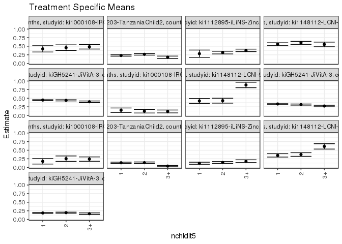

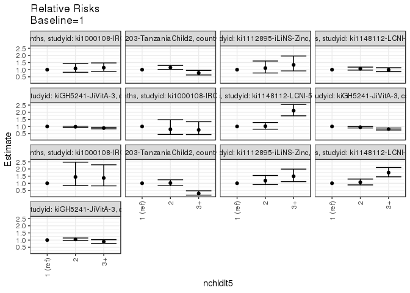

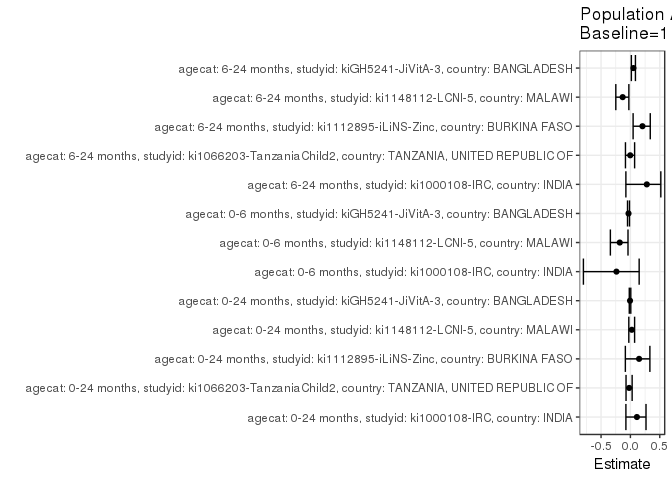

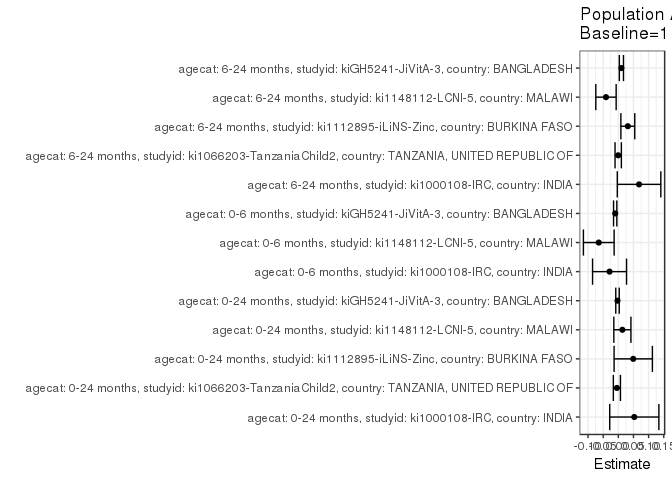

## Results Table

### Parameter: TSM

| agecat | studyid | country | intervention_level | baseline_level | estimate | ci_lower | ci_upper |
| --- | --- | --- | --- | --- | --- | --- | --- |
| 0-24 months | ki1000108-IRC | INDIA | 1 | NA | 0.4228969 | 0.3319146 | 0.5138792 |
| 0-24 months | ki1000108-IRC | INDIA | 2 | NA | 0.4579277 | 0.3767166 | 0.5391387 |
| 0-24 months | ki1000108-IRC | INDIA | 3+ | NA | 0.4835556 | 0.4179064 | 0.5492047 |
| 0-24 months | ki1066203-TanzaniaChild2 | TANZANIA, UNITED REPUBLIC OF | 1 | NA | 0.2307872 | 0.2109353 | 0.2506391 |
| 0-24 months | ki1066203-TanzaniaChild2 | TANZANIA, UNITED REPUBLIC OF | 2 | NA | 0.2650142 | 0.2406981 | 0.2893302 |
| 0-24 months | ki1066203-TanzaniaChild2 | TANZANIA, UNITED REPUBLIC OF | 3+ | NA | 0.1787664 | 0.1447736 | 0.2127592 |
| 0-24 months | ki1112895-iLiNS-Zinc | BURKINA FASO | 1 | NA | 0.2832495 | 0.1775269 | 0.3889721 |
| 0-24 months | ki1112895-iLiNS-Zinc | BURKINA FASO | 2 | NA | 0.3151514 | 0.2752478 | 0.3550549 |
| 0-24 months | ki1112895-iLiNS-Zinc | BURKINA FASO | 3+ | NA | 0.3791014 | 0.3427165 | 0.4154862 |
| 0-24 months | ki1148112-LCNI-5 | MALAWI | 1 | NA | 0.5580859 | 0.5158888 | 0.6002830 |
| 0-24 months | ki1148112-LCNI-5 | MALAWI | 2 | NA | 0.5981511 | 0.5551712 | 0.6411310 |
| 0-24 months | ki1148112-LCNI-5 | MALAWI | 3+ | NA | 0.5523492 | 0.4847363 | 0.6199622 |
| 0-24 months | kiGH5241-JiVitA-3 | BANGLADESH | 1 | NA | 0.4466064 | 0.4370436 | 0.4561693 |
| 0-24 months | kiGH5241-JiVitA-3 | BANGLADESH | 2 | NA | 0.4376984 | 0.4213510 | 0.4540457 |
| 0-24 months | kiGH5241-JiVitA-3 | BANGLADESH | 3+ | NA | 0.3968277 | 0.3739685 | 0.4196869 |
| 0-6 months | ki1000108-IRC | INDIA | 1 | NA | 0.1509606 | 0.0862998 | 0.2156214 |
| 0-6 months | ki1000108-IRC | INDIA | 2 | NA | 0.1213075 | 0.0694960 | 0.1731191 |
| 0-6 months | ki1000108-IRC | INDIA | 3+ | NA | 0.1145379 | 0.0723627 | 0.1567130 |
| 0-6 months | ki1148112-LCNI-5 | MALAWI | 1 | NA | 0.4204474 | 0.3494961 | 0.4913986 |
| 0-6 months | ki1148112-LCNI-5 | MALAWI | 2 | NA | 0.4282741 | 0.3567611 | 0.4997872 |
| 0-6 months | ki1148112-LCNI-5 | MALAWI | 3+ | NA | 0.8854740 | 0.8059933 | 0.9649547 |
| 0-6 months | kiGH5241-JiVitA-3 | BANGLADESH | 1 | NA | 0.3322992 | 0.3234029 | 0.3411954 |
| 0-6 months | kiGH5241-JiVitA-3 | BANGLADESH | 2 | NA | 0.3152466 | 0.2988882 | 0.3316051 |
| 0-6 months | kiGH5241-JiVitA-3 | BANGLADESH | 3+ | NA | 0.2730287 | 0.2511140 | 0.2949435 |
| 6-24 months | ki1000108-IRC | INDIA | 1 | NA | 0.1763822 | 0.0977049 | 0.2550594 |
| 6-24 months | ki1000108-IRC | INDIA | 2 | NA | 0.2539792 | 0.1749966 | 0.3329619 |
| 6-24 months | ki1000108-IRC | INDIA | 3+ | NA | 0.2416164 | 0.1786604 | 0.3045725 |
| 6-24 months | ki1066203-TanzaniaChild2 | TANZANIA, UNITED REPUBLIC OF | 1 | NA | 0.1346880 | 0.1167833 | 0.1525927 |
| 6-24 months | ki1066203-TanzaniaChild2 | TANZANIA, UNITED REPUBLIC OF | 2 | NA | 0.1366684 | 0.1151823 | 0.1581544 |
| 6-24 months | ki1066203-TanzaniaChild2 | TANZANIA, UNITED REPUBLIC OF | 3+ | NA | 0.0382067 | 0.0195115 | 0.0569019 |
| 6-24 months | ki1112895-iLiNS-Zinc | BURKINA FASO | 1 | NA | 0.1211336 | 0.0909487 | 0.1513186 |
| 6-24 months | ki1112895-iLiNS-Zinc | BURKINA FASO | 2 | NA | 0.1434812 | 0.1164155 | 0.1705469 |
| 6-24 months | ki1112895-iLiNS-Zinc | BURKINA FASO | 3+ | NA | 0.1804837 | 0.1400808 | 0.2208866 |
| 6-24 months | ki1148112-LCNI-5 | MALAWI | 1 | NA | 0.3498461 | 0.3009262 | 0.3987661 |
| 6-24 months | ki1148112-LCNI-5 | MALAWI | 2 | NA | 0.3746792 | 0.3223189 | 0.4270396 |
| 6-24 months | ki1148112-LCNI-5 | MALAWI | 3+ | NA | 0.6108799 | 0.5329541 | 0.6888057 |
| 6-24 months | kiGH5241-JiVitA-3 | BANGLADESH | 1 | NA | 0.1868301 | 0.1766405 | 0.1970198 |
| 6-24 months | kiGH5241-JiVitA-3 | BANGLADESH | 2 | NA | 0.1959574 | 0.1810611 | 0.2108538 |
| 6-24 months | kiGH5241-JiVitA-3 | BANGLADESH | 3+ | NA | 0.1662219 | 0.1439503 | 0.1884935 |

### Parameter: E(Y)

| agecat | studyid | country | intervention_level | baseline_level | estimate | ci_lower | ci_upper |
| --- | --- | --- | --- | --- | --- | --- | --- |
| 0-24 months | ki1000108-IRC | INDIA | NA | NA | 0.4756098 | 0.4272105 | 0.5240091 |
| 0-24 months | ki1066203-TanzaniaChild2 | TANZANIA, UNITED REPUBLIC OF | NA | NA | 0.2259958 | 0.2092071 | 0.2427845 |
| 0-24 months | ki1112895-iLiNS-Zinc | BURKINA FASO | NA | NA | 0.3324969 | 0.2814472 | 0.3835465 |
| 0-24 months | ki1148112-LCNI-5 | MALAWI | NA | NA | 0.5714286 | 0.5373697 | 0.6054874 |
| 0-24 months | kiGH5241-JiVitA-3 | BANGLADESH | NA | NA | 0.4438237 | 0.4363002 | 0.4513472 |
| 0-6 months | ki1000108-IRC | INDIA | NA | NA | 0.1219512 | 0.0902381 | 0.1536643 |
| 0-6 months | ki1148112-LCNI-5 | MALAWI | NA | NA | 0.3558052 | 0.2982716 | 0.4133389 |
| 0-6 months | kiGH5241-JiVitA-3 | BANGLADESH | NA | NA | 0.3219246 | 0.3151663 | 0.3286829 |
| 6-24 months | ki1000108-IRC | INDIA | NA | NA | 0.2448378 | 0.1989973 | 0.2906782 |
| 6-24 months | ki1066203-TanzaniaChild2 | TANZANIA, UNITED REPUBLIC OF | NA | NA | 0.1342391 | 0.1186581 | 0.1498201 |
| 6-24 months | ki1112895-iLiNS-Zinc | BURKINA FASO | NA | NA | 0.1524460 | 0.1260328 | 0.1788591 |
| 6-24 months | ki1148112-LCNI-5 | MALAWI | NA | NA | 0.3090278 | 0.2712581 | 0.3467975 |
| 6-24 months | kiGH5241-JiVitA-3 | BANGLADESH | NA | NA | 0.1969765 | 0.1889146 | 0.2050384 |

### Parameter: RR

| agecat | studyid | country | intervention_level | baseline_level | estimate | ci_lower | ci_upper |
| --- | --- | --- | --- | --- | --- | --- | --- |
| 0-24 months | ki1000108-IRC | INDIA | 1 | 1 | 1.0000000 | 1.0000000 | 1.0000000 |
| 0-24 months | ki1000108-IRC | INDIA | 2 | 1 | 1.0828353 | 0.8197597 | 1.4303366 |
| 0-24 months | ki1000108-IRC | INDIA | 3+ | 1 | 1.1434361 | 0.8874063 | 1.4733344 |
| 0-24 months | ki1066203-TanzaniaChild2 | TANZANIA, UNITED REPUBLIC OF | 1 | 1 | 1.0000000 | 1.0000000 | 1.0000000 |
| 0-24 months | ki1066203-TanzaniaChild2 | TANZANIA, UNITED REPUBLIC OF | 2 | 1 | 1.1483052 | 1.0137988 | 1.3006572 |
| 0-24 months | ki1066203-TanzaniaChild2 | TANZANIA, UNITED REPUBLIC OF | 3+ | 1 | 0.7745940 | 0.6292807 | 0.9534630 |
| 0-24 months | ki1112895-iLiNS-Zinc | BURKINA FASO | 1 | 1 | 1.0000000 | 1.0000000 | 1.0000000 |
| 0-24 months | ki1112895-iLiNS-Zinc | BURKINA FASO | 2 | 1 | 1.1126283 | 0.7699874 | 1.6077427 |
| 0-24 months | ki1112895-iLiNS-Zinc | BURKINA FASO | 3+ | 1 | 1.3384009 | 0.9153422 | 1.9569915 |
| 0-24 months | ki1148112-LCNI-5 | MALAWI | 1 | 1 | 1.0000000 | 1.0000000 | 1.0000000 |
| 0-24 months | ki1148112-LCNI-5 | MALAWI | 2 | 1 | 1.0717904 | 0.9724599 | 1.1812669 |
| 0-24 months | ki1148112-LCNI-5 | MALAWI | 3+ | 1 | 0.9897208 | 0.8621673 | 1.1361452 |
| 0-24 months | kiGH5241-JiVitA-3 | BANGLADESH | 1 | 1 | 1.0000000 | 1.0000000 | 1.0000000 |
| 0-24 months | kiGH5241-JiVitA-3 | BANGLADESH | 2 | 1 | 0.9800539 | 0.9404435 | 1.0213326 |
| 0-24 months | kiGH5241-JiVitA-3 | BANGLADESH | 3+ | 1 | 0.8885400 | 0.8371085 | 0.9431314 |
| 0-6 months | ki1000108-IRC | INDIA | 1 | 1 | 1.0000000 | 1.0000000 | 1.0000000 |
| 0-6 months | ki1000108-IRC | INDIA | 2 | 1 | 0.8035707 | 0.4391243 | 1.4704855 |
| 0-6 months | ki1000108-IRC | INDIA | 3+ | 1 | 0.7587267 | 0.4318681 | 1.3329679 |
| 0-6 months | ki1148112-LCNI-5 | MALAWI | 1 | 1 | 1.0000000 | 1.0000000 | 1.0000000 |
| 0-6 months | ki1148112-LCNI-5 | MALAWI | 2 | 1 | 1.0186154 | 0.8115006 | 1.2785909 |
| 0-6 months | ki1148112-LCNI-5 | MALAWI | 3+ | 1 | 2.1060282 | 1.7447977 | 2.5420452 |
| 0-6 months | kiGH5241-JiVitA-3 | BANGLADESH | 1 | 1 | 1.0000000 | 1.0000000 | 1.0000000 |
| 0-6 months | kiGH5241-JiVitA-3 | BANGLADESH | 2 | 1 | 0.9486831 | 0.8965961 | 1.0037961 |
| 0-6 months | kiGH5241-JiVitA-3 | BANGLADESH | 3+ | 1 | 0.8216353 | 0.7556795 | 0.8933478 |
| 6-24 months | ki1000108-IRC | INDIA | 1 | 1 | 1.0000000 | 1.0000000 | 1.0000000 |
| 6-24 months | ki1000108-IRC | INDIA | 2 | 1 | 1.4399370 | 0.8367175 | 2.4780392 |
| 6-24 months | ki1000108-IRC | INDIA | 3+ | 1 | 1.3698460 | 0.8179776 | 2.2940459 |
| 6-24 months | ki1066203-TanzaniaChild2 | TANZANIA, UNITED REPUBLIC OF | 1 | 1 | 1.0000000 | 1.0000000 | 1.0000000 |
| 6-24 months | ki1066203-TanzaniaChild2 | TANZANIA, UNITED REPUBLIC OF | 2 | 1 | 1.0147035 | 0.8274348 | 1.2443557 |
| 6-24 months | ki1066203-TanzaniaChild2 | TANZANIA, UNITED REPUBLIC OF | 3+ | 1 | 0.2836684 | 0.1709770 | 0.4706349 |
| 6-24 months | ki1112895-iLiNS-Zinc | BURKINA FASO | 1 | 1 | 1.0000000 | 1.0000000 | 1.0000000 |
| 6-24 months | ki1112895-iLiNS-Zinc | BURKINA FASO | 2 | 1 | 1.1844873 | 0.9084771 | 1.5443538 |
| 6-24 months | ki1112895-iLiNS-Zinc | BURKINA FASO | 3+ | 1 | 1.4899556 | 1.1143949 | 1.9920835 |
| 6-24 months | ki1148112-LCNI-5 | MALAWI | 1 | 1 | 1.0000000 | 1.0000000 | 1.0000000 |
| 6-24 months | ki1148112-LCNI-5 | MALAWI | 2 | 1 | 1.0709829 | 0.8852589 | 1.2956710 |
| 6-24 months | ki1148112-LCNI-5 | MALAWI | 3+ | 1 | 1.7461388 | 1.4500579 | 2.1026752 |
| 6-24 months | kiGH5241-JiVitA-3 | BANGLADESH | 1 | 1 | 1.0000000 | 1.0000000 | 1.0000000 |
| 6-24 months | kiGH5241-JiVitA-3 | BANGLADESH | 2 | 1 | 1.0488535 | 0.9617577 | 1.1438365 |
| 6-24 months | kiGH5241-JiVitA-3 | BANGLADESH | 3+ | 1 | 0.8896955 | 0.7710224 | 1.0266342 |

### Parameter: PAR

| agecat | studyid | country | intervention_level | baseline_level | estimate | ci_lower | ci_upper |
| --- | --- | --- | --- | --- | --- | --- | --- |
| 0-24 months | ki1000108-IRC | INDIA | 1 | NA | 0.0527129 | -0.0285093 | 0.1339351 |
| 0-24 months | ki1066203-TanzaniaChild2 | TANZANIA, UNITED REPUBLIC OF | 1 | NA | -0.0047914 | -0.0165107 | 0.0069279 |
| 0-24 months | ki1112895-iLiNS-Zinc | BURKINA FASO | 1 | NA | 0.0492474 | -0.0140059 | 0.1125006 |
| 0-24 months | ki1148112-LCNI-5 | MALAWI | 1 | NA | 0.0133427 | -0.0149012 | 0.0415866 |
| 0-24 months | kiGH5241-JiVitA-3 | BANGLADESH | 1 | NA | -0.0027827 | -0.0085184 | 0.0029529 |
| 0-6 months | ki1000108-IRC | INDIA | 1 | NA | -0.0290094 | -0.0851361 | 0.0271173 |
| 0-6 months | ki1148112-LCNI-5 | MALAWI | 1 | NA | -0.0646421 | -0.1153900 | -0.0138943 |
| 0-6 months | kiGH5241-JiVitA-3 | BANGLADESH | 1 | NA | -0.0103746 | -0.0157750 | -0.0049741 |
| 6-24 months | ki1000108-IRC | INDIA | 1 | NA | 0.0684556 | -0.0034468 | 0.1403579 |
| 6-24 months | ki1066203-TanzaniaChild2 | TANZANIA, UNITED REPUBLIC OF | 1 | NA | -0.0004489 | -0.0108942 | 0.0099965 |
| 6-24 months | ki1112895-iLiNS-Zinc | BURKINA FASO | 1 | NA | 0.0313123 | 0.0083991 | 0.0542256 |
| 6-24 months | ki1148112-LCNI-5 | MALAWI | 1 | NA | -0.0408184 | -0.0744217 | -0.0072150 |
| 6-24 months | kiGH5241-JiVitA-3 | BANGLADESH | 1 | NA | 0.0101464 | 0.0032920 | 0.0170008 |

### Parameter: PAF

| agecat | studyid | country | intervention_level | baseline_level | estimate | ci_lower | ci_upper |
| --- | --- | --- | --- | --- | --- | --- | --- |
| 0-24 months | ki1000108-IRC | INDIA | 1 | NA | 0.1108322 | -0.0767447 | 0.2657318 |
| 0-24 months | ki1066203-TanzaniaChild2 | TANZANIA, UNITED REPUBLIC OF | 1 | NA | -0.0212013 | -0.0745276 | 0.0294784 |
| 0-24 months | ki1112895-iLiNS-Zinc | BURKINA FASO | 1 | NA | 0.1481138 | -0.0861449 | 0.3318478 |
| 0-24 months | ki1148112-LCNI-5 | MALAWI | 1 | NA | 0.0233497 | -0.0272349 | 0.0714433 |
| 0-24 months | kiGH5241-JiVitA-3 | BANGLADESH | 1 | NA | -0.0062699 | -0.0192744 | 0.0065688 |
| 0-6 months | ki1000108-IRC | INDIA | 1 | NA | -0.2378771 | -0.8007237 | 0.1490424 |
| 0-6 months | ki1148112-LCNI-5 | MALAWI | 1 | NA | -0.1816784 | -0.3413406 | -0.0410211 |
| 0-6 months | kiGH5241-JiVitA-3 | BANGLADESH | 1 | NA | -0.0322267 | -0.0491126 | -0.0156125 |
| 6-24 months | ki1000108-IRC | INDIA | 1 | NA | 0.2795957 | -0.0770543 | 0.5181465 |
| 6-24 months | ki1066203-TanzaniaChild2 | TANZANIA, UNITED REPUBLIC OF | 1 | NA | -0.0033437 | -0.0842934 | 0.0715625 |
| 6-24 months | ki1112895-iLiNS-Zinc | BURKINA FASO | 1 | NA | 0.2053996 | 0.0459988 | 0.3381666 |
| 6-24 months | ki1148112-LCNI-5 | MALAWI | 1 | NA | -0.1320864 | -0.2486540 | -0.0264009 |
| 6-24 months | kiGH5241-JiVitA-3 | BANGLADESH | 1 | NA | 0.0515107 | 0.0161616 | 0.0855897 |